# BikeShare Problem

Juliet Thistleton

2023-10-18

##### Citation

This homework assignment is largely borrowed from Coursework created Prof. Alexandra Chouldechova at Carnegie Mellon University. I have modified slightly and am using in accordance with the Creative Commons License:

Creative Commons Attribution-NonCommercial-ShareAlike 4.0 International License(http://creativecommons.org/licenses/by-nc-sa/4.0/)

### Housekeeping - packages to be used.

We will give preference to the “tidyverse” of packages related to “Tidy Data.”

```r
library(knitr)
library(tidyverse) # loads ggplot2, dplyr,tidyr,readr,purr,tibble
library(broom)  # because I find it useful

cbPalette <- c("#999999", "#E69F00", "#56B4E9", "#009E73", "#F0E442", "#0072B2", "#D55E00", "#CC79A7")

options(scipen = 4)  # make output prefer not to use scientific notation
```

### Introduction: Bikeshare data

For this problem we’ll be working with two years of bikeshare data from the Capital Bikeshare system in Washington DC. The dataset contains daily bikeshare counts, along with daily measurements on environmental and seasonal information that may affect the bikesharing.

### Data pre-processing

Let’s start by loading the data.

```r
bikes <- read.csv("http://www.andrew.cmu.edu/user/achoulde/95791/data/bikes.csv", header = TRUE)

# Transform temp and atemp to degrees C instead of [0,1] scale
# Transform humidity to %
# Transform wind speed (multiply by 67, the normalizing value)

bikes <- mutate(bikes,
                   temp = 47 * temp - 8,
                   atemp = 66 * atemp - 16,
                   hum = 100 * hum,
                   windspeed = 67 * windspeed)

# The recode() command from the dplyr library allows us to easily
# rename values in our variables.  Below we use this command to change season
# from numeric codings to season names.

bikes <- mutate(bikes,
                   season = recode(season, `1`="Winter",`2`="Spring",
                                      `3`="Summer", `4`="Fall"))
```

Let’s look at some boxplots of how bikeshare ride count varies with season.

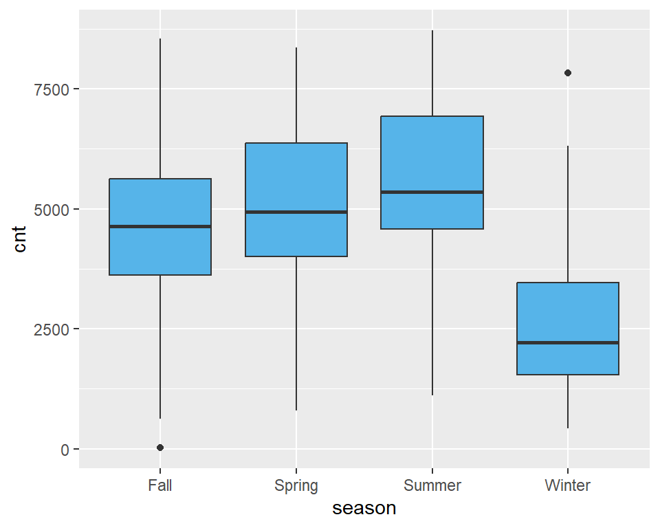

```r
qplot(data = bikes, x = season, y = cnt, fill = I(cbPalette[3]), geom = "boxplot")
```

There’s something funny going on here. Instead of showing up in seasonal order, the seasons in the plot are showing up in **alphabetical order**. The following command reorders the seasons appropriately.

```r
bikes <- mutate(bikes, season = factor(season, levels = c("Winter", "Spring", "Summer", "Fall")))
```

Now let’s try that plot again.

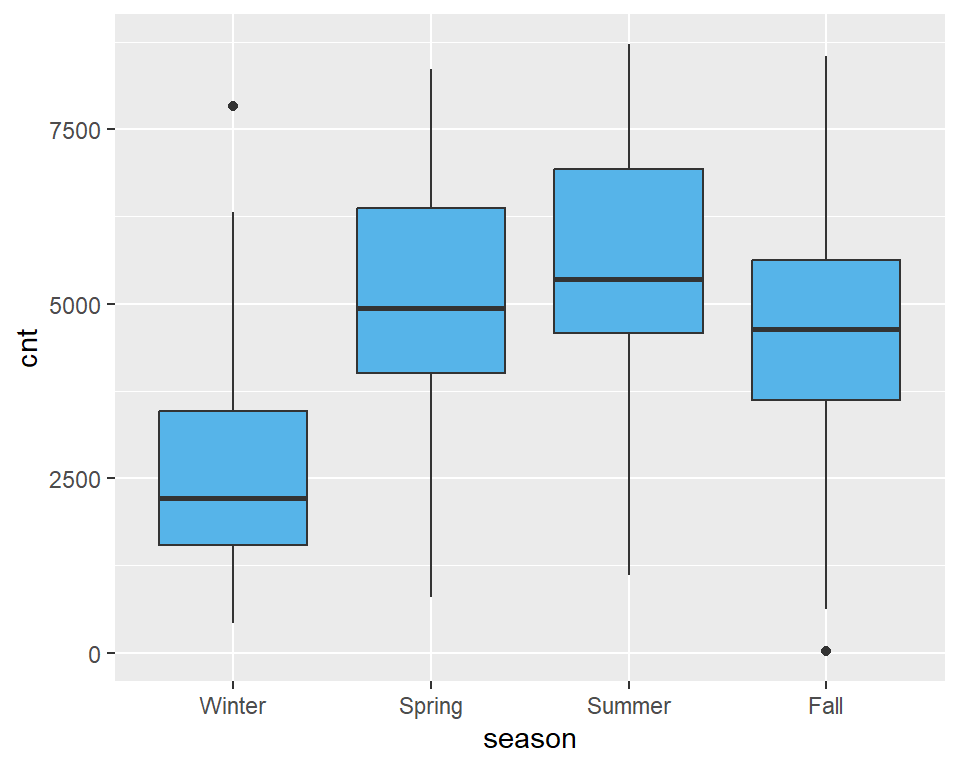

```r
qplot(data = bikes, x = season, y = cnt, fill = I(cbPalette[3]), geom = "boxplot")
```

Here’s information on what the variables mean.

- instant: record index
  - dteday : date
  - season : season (1:Winter, 2:Spring, 3:Summer, 4:Fall)
  - yr : year (0: 2011, 1:2012)
  - mnth : month ( 1 to 12)
  - hr : hour (0 to 23)
  - holiday : weather day is holiday or not (extracted from http://dchr.dc.gov/page/holiday-schedule)
  - weekday : day of the week
  - workingday : if day is neither weekend nor holiday is 1, otherwise is 0.
  - weathersit :
    - 1: Clear, Few clouds, Partly cloudy, Partly cloudy
    - 2: Mist + Cloudy, Mist + Broken clouds, Mist + Few clouds, Mist
    - 3: Light Snow, Light Rain + Thunderstorm + Scattered clouds, Light Rain + Scattered clouds
    - 4: Heavy Rain + Ice Pallets + Thunderstorm + Mist, Snow + Fog
  - temp : Temperature in Celsius.
  - atemp: `feels like’ temperature in Celsius.
  - hum: Normalized humidity. The values are divided to 100 (max)
  - windspeed: Normalized wind speed. The values are divided to 67 (max)
  - casual: count of casual users
  - registered: count of registered users
  - cnt: count of total rental bikes including both casual and registered

### Problem 1: Qualitative predictors

> The Season variable is an example of what’s called a *qualitative* or *categorical* predictor. In R, such variables are called `factors`. This problems gets to fit a model with a qualitative predictor and to interpret the findings.

##### **(a)** Suppose we were interested in predicting the count of total bike rentals by using the *season* as the predictor. Fit a linear (using the lm command) regression model with `cnt` as the response and `season` as the input. Use the `tidy()` and `kable()` commands to produce a nice looking coefficients table.

(Maybe look at https://rstudio-pubs-static.s3.amazonaws.com/58870_136d938b1ffd427ab5b30a98b663b127.html for an idea)

```r
lmfit <- lm(cnt ~season, data = bikes)
tidy(lmfit)
```

```
## # A tibble: 4 × 5
##   term         estimate std.error statistic  p.value
##   <chr>           <dbl>     <dbl>     <dbl>    <dbl>
## 1 (Intercept)     2604.      117.      22.3 1.55e-84
## 2 seasonSpring    2388.      164.      14.5 3.04e-42
## 3 seasonSummer    3040.      163.      18.6 1.60e-63
## 4 seasonFall      2124.      166.      12.8 4.24e-34
```

```r
summary(lmfit)
```

```
##
## Call:
## lm(formula = cnt ~ season, data = bikes)
##
## Residuals:
##     Min      1Q  Median      3Q     Max
## -4706.2 -1065.6  -181.3  1219.2  5231.9
##
## Coefficients:
##              Estimate Std. Error t value Pr(>|t|)
## (Intercept)    2604.1      116.6   22.33   <2e-16 ***
## seasonSpring   2388.2      164.2   14.54   <2e-16 ***
## seasonSummer   3040.2      163.4   18.61   <2e-16 ***
## seasonFall     2124.0      165.6   12.83   <2e-16 ***
## ---
## Signif. codes:  0 '***' 0.001 '**' 0.01 '*' 0.05 '.' 0.1 ' ' 1
##
## Residual standard error: 1569 on 727 degrees of freedom
## Multiple R-squared:  0.347,  Adjusted R-squared:  0.3443
## F-statistic: 128.8 on 3 and 727 DF,  p-value: < 2.2e-16
```

##### **(b)** How many total coefficients are there in the model?

There were 4 total coefiicients in the model.

##### **(d)** Interpret the coefficients of `season` in the model.

The season coefficients are predictive of the number of bikes shared for that season. All of the seasons have a very significant p value, meaning the seasons are a good predictor for the number of bikes shared.

### Problem 2: Multiple linear regression

> In this problem we’ll practice fitting and interpreting the results of a multiple linear regression.

##### **(a)** Fit a regression model with `cnt` as the response and the following variables as inputs: `temp`, `atemp`, `mnth`, `hum`, `windspeed`. Produce a nice looking coefficients table.

```r
lmfit2 <- lm(cnt ~temp + atemp + mnth + hum + windspeed, data = bikes)
tidy(lmfit2)
```

```
## # A tibble: 6 × 5
##   term        estimate std.error statistic  p.value
##   <chr>          <dbl>     <dbl>     <dbl>    <dbl>
## 1 (Intercept)   5058.     343.      14.8   2.60e-43
## 2 temp            45.4     47.4      0.957 3.39e- 1
## 3 atemp           72.0     38.1      1.89  5.94e- 2
## 4 mnth            95.0     15.7      6.04  2.50e- 9
## 5 hum            -35.3      3.80    -9.28  1.98e-19
## 6 windspeed      -59.2     10.6     -5.58  3.39e- 8
```

```r
summary(lmfit2)
```

```
##
## Call:
## lm(formula = cnt ~ temp + atemp + mnth + hum + windspeed, data = bikes)
##
## Residuals:
##     Min      1Q  Median      3Q     Max
## -4829.6  -992.7  -188.5  1089.4  3615.1
##
## Coefficients:
##             Estimate Std. Error t value     Pr(>|t|)
## (Intercept) 5057.781    342.624  14.762      < 2e-16 ***
## temp          45.387     47.414   0.957       0.3388
## atemp         72.014     38.138   1.888       0.0594 .
## mnth          95.040     15.742   6.037 0.0000000025 ***
## hum          -35.262      3.801  -9.277      < 2e-16 ***
## windspeed    -59.159     10.601  -5.580 0.0000000339 ***
## ---
## Signif. codes:  0 '***' 0.001 '**' 0.01 '*' 0.05 '.' 0.1 ' ' 1
##
## Residual standard error: 1389 on 725 degrees of freedom
## Multiple R-squared:  0.4895, Adjusted R-squared:  0.486
## F-statistic:   139 on 5 and 725 DF,  p-value: < 2.2e-16
```

##### **(b)** Interpret the coefficients of `temp`, `mnth` and `hum` in the model.

This is how the overall temperature, month, and humidity effect the linear regression. ‘temp’ and ‘atemp’ are not good predictors of the total bikes shared, but ‘mnth’, ‘hum’, and ‘windspeed’ are.

##### **(c)** Which predictors are associated with increased ridership? Which predictors are associated with decreased ridership?

‘temp’, ‘atemp’ and ‘mnth’ are associated with increased ridership. ‘hum’ and ‘windspeed’ are associated with decreased ridership.

##### **(d)** Which predictors are statistically significant at the 0.05 level?

‘mnth’, ‘hum’, and ‘windspeed’.

### Problem 3: Dealing with collinearity

> As you probably already know from your most recent regression class, *collinear* or *highly correlated* predictors can make interpreting regression coefficients problematic. In this problem you will try to diagnose and address collinearity issues in the data.

##### **(a)** Use the `pairs()` function on the set of variables used in **Problem 2** to check if any of the predictor variables are highly correlated with one another. Your pairs plot should have scatterplots above the diagonal, and correlations below the diagonal.

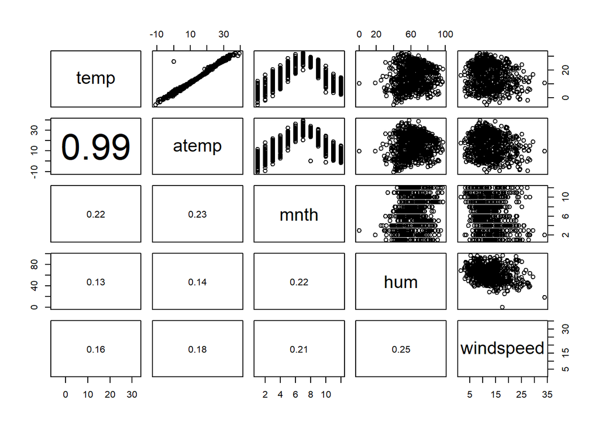

```r
var_names <- c("temp", "atemp", "mnth", "hum", "windspeed")

panel.cor <- function(x, y, digits = 2, prefix = "", cex.cor, ...)
{
    usr <- par("usr"); on.exit(par(usr))
    par(usr = c(0, 1, 0, 1))
    r <- abs(cor(x, y))
    txt <- format(c(r, 0.123456789), digits = digits)[1]
    txt <- paste0(prefix, txt)
    if(missing(cex.cor)) cex.cor <- 0.8/strwidth(txt)
    text(0.5, 0.5, txt, cex = pmax(1, cex.cor * r))
}
pairs(bikes[,var_names], lower.panel = panel.cor)
```

**Hint**: A complete example of how to use the `pairs()` command to construct such plots may be found here: [Pairs plot example](http://www.andrew.cmu.edu/user/achoulde/94842/lectures/lecture08/lecture08-94842.html#collinearity-and-pairs-plots)

##### **(b)** Are any of the predictors highly correlated? Are you surprised that these predictors are highly correlated, or can you think of a reason for why it makes sense that they should be correlated?

Temp and atemp are highly correlated. I am not surprised these two are correlated, as the temperature and what the temperature feels like should be close together. If the temp is 20 degrees Celsius, then it would make no logical sense if the atemp was then zero degrees celsius.

##### **(c)** Refit your regression model, but this time **omit** the `temp` variable. Display the coefficients table for this model.

```r
bikes.lm <- lm(cnt ~atemp + mnth + hum + windspeed, data = bikes)
tidy(bikes.lm)
```

```
## # A tibble: 5 × 5
##   term        estimate std.error statistic  p.value
##   <chr>          <dbl>     <dbl>     <dbl>    <dbl>
## 1 (Intercept)   5187.     315.       16.5  5.56e-52
## 2 atemp          108.       4.97     21.8  2.74e-81
## 3 mnth            95.0     15.7       6.04 2.51e- 9
## 4 hum            -35.4      3.80     -9.34 1.18e-19
## 5 windspeed      -57.4     10.4      -5.50 5.33e- 8
```

```r
summary(bikes.lm)$coefficients
```

```
##               Estimate Std. Error   t value     Pr(>|t|)
## (Intercept) 5186.62385 315.060725 16.462299 5.560267e-52
## atemp        108.21019   4.969790 21.773595 2.738696e-81
## mnth          95.01639  15.740911  6.036270 2.514975e-09
## hum          -35.44625   3.796028 -9.337722 1.177718e-19
## windspeed    -57.39672  10.439766 -5.497893 5.326398e-08
```

##### **(d)** What is the coefficient of `atemp` in this new model? Is it very different from the `atemp` coefficient estimated in part **(b)**? Is it statistically significant? Explain your findings.

# Optional Material Below

### Problem 4: Exploring non-linearities

> **Hint**: For this problem, you will find it useful to know about the `jitter` feature in graphics. [Begin by reviewing the code at this link](http://www.andrew.cmu.edu/user/achoulde/94842/misc/extra_tips.html#jittering-points), and be sure to use what you feel to be an appropriate amount of jitter in your plots for **(a)**, **(b)** and **(c)**. You **should not** use jitter for parts **(d)** onward.

##### **(a)** Using `ggplot2` graphics, construct a scatterplot of `cnt` (bikeshare count) across `mnth` (month of the year). Describe what you see. Does a linear relationship appear to be a good way of modeling how bikeshare count varies with month?

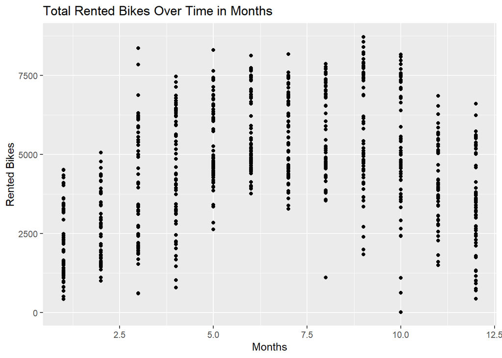

```r
ggplot(bikes, (aes(x = bikes$mnth, y = bikes$cnt))) + geom_point() + labs(title = "Total Rented Bikes Over Time in Months", x = "Months", y = "Rented Bikes")
```

The data points for each month of total rented bikes are shown. This results in a column-like structure, as the data points are grouped by month, Due to the grouping by months, a linear relationship does not seem to be the best way to model how bikeshare count varies by month.

##### **(b)** Use `ggplot2`’s `stat_smooth()` overlays to try out *different degree polynomial fits* for modeling the relationship between `cnt` and `month`. Display the lowest degree polynomial fit that appears to nicely capture the trends in the data. Explain your choice.

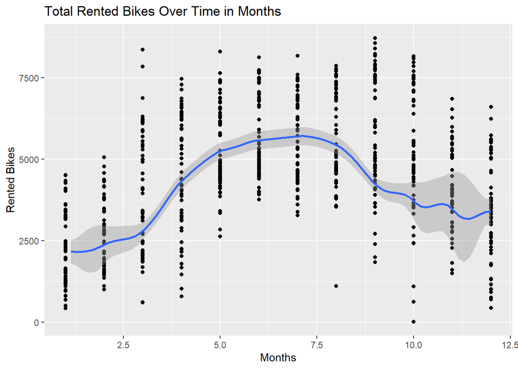

```r
ggplot(bikes, (aes(x = bikes$mnth, y = bikes$cnt))) +  geom_point() + stat_smooth(formula = y ~ poly(x,2)) + labs(title = "Total Rented Bikes Over Time in Months", x = "Months", y = "Rented Bikes")
```

##### **(c)** Use `ggplot2`’s `stat_smooth()` overlays to try out *different step functions* for modeling the relationship between `cnt` and `month`. Display the model with the smallest number of “breaks” or “cuts” that nicely captures the trends in the data. Explain your choice.

You may want to look at

https://www.andrew.cmu.edu/user/achoulde/95791/lectures/code/week1.html

to get some options.

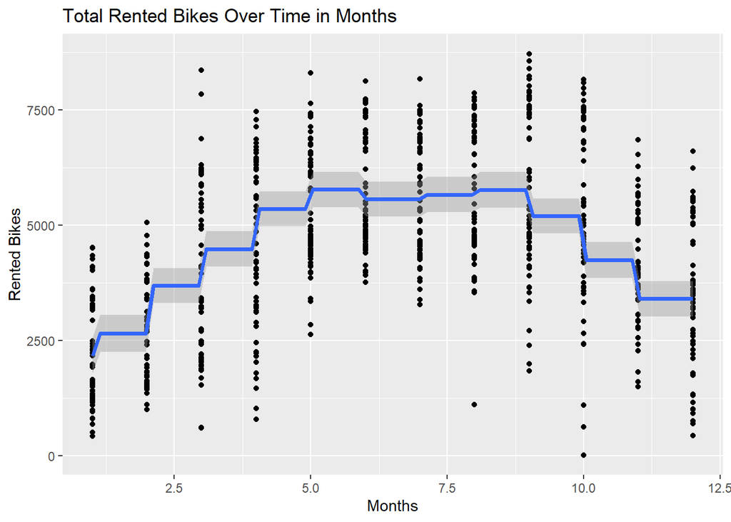

```r
ggplot(bikes, (aes(x = bikes$mnth, y = bikes$cnt))) +  geom_point() +    stat_smooth(method = "lm", formula = y ~ cut(x, breaks = c(-Inf,1, 2, 3, 4, 5, 6, 7, 8, 9, 10 ,11, 12, Inf)), lwd = 1.25) + labs(title = "Total Rented Bikes Over Time in Months", x = "Months", y = "Rented Bikes")
```

I put breaks at 1, 2, 3, 4, 5, 6, 7, 8, 9, 10, 11, and 12 because those represent the months.

##### Which do you think better describes the relationship between `cnt` and `mnth`: Polynomials, or Step Functions? Explain your answer.

Step functions because the relationship between ‘cnt and ’mnth’ is grouped vertically per month.

##### **(d)** Repeat parts **(a)** and **(b)** to determine appropriate degree polynomials for modeling the relationship between `cnt` and the other inputs: `atemp`, `hum` and `windspeed`. Summarize your choices. (Note: your polynomials can have different degrees for different inputs.)

## ‘cnt’ Vs ‘atemp’

[figure not shown]

```r
ggplot(bikes, (aes(x = atemp, y = cnt))) +  geom_point() + stat_smooth(formula = y ~ poly(x,1)) + labs(title = "Total Rented Bikes Vs 'Feels like' Temp", x = "Months", y = "Rented Bikes")
```

## ‘cnt’ Vs ‘hum’

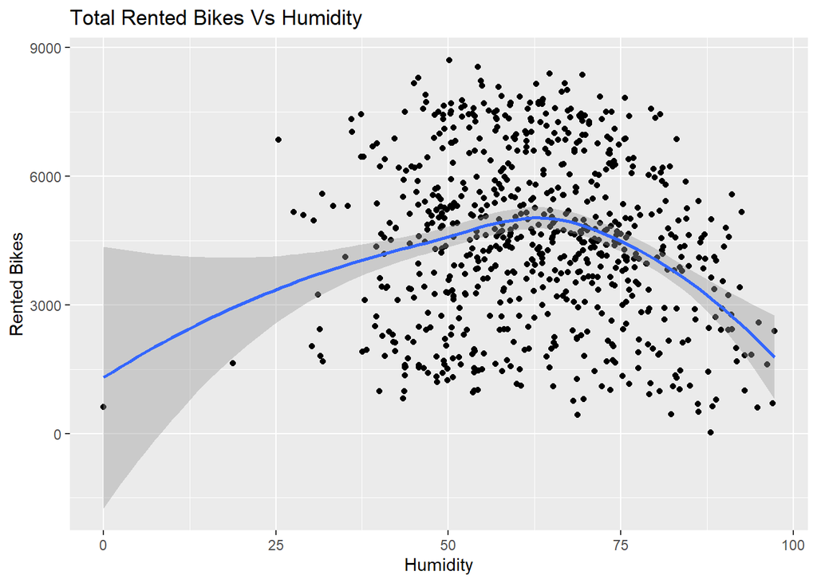

```r
ggplot(bikes, (aes(x = hum, y = cnt))) +  geom_point() + stat_smooth(formula = y ~ poly(x,1)) + labs(title = "Total Rented Bikes Vs Humidity", x = "Humidity", y = "Rented Bikes")
```

## ‘cnt’ Vs ‘windspeed’

[figure not shown]

```r
ggplot(bikes, (aes(x = windspeed, y = cnt))) +  geom_point() + stat_smooth(formula = y ~ poly(x,1)) + labs(title = "Total Rented Bikes Vs Windspeed", x = "Months", y = "Windspeed")
```

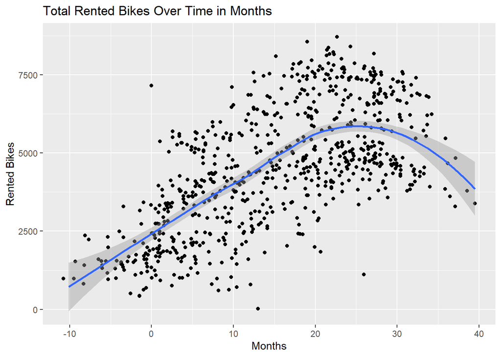

```r
ggplot(bikes, (aes(x = atemp, mnth, hum, windspeed, y = cnt))) +  geom_point() + stat_smooth(formula = y ~ poly(x,1)) + labs(title = "Total Rented Bikes Over Time in Months", x = "Months", y = "Rented Bikes")
```

```r
all_lm <- lm(cnt ~atemp + mnth, + hum + windspeed, data = bikes)
paste("cnt over months with variables atemp, mnth, hum, windspeed")
```

```
## [1] "cnt over months with variables atemp, mnth, hum, windspeed"
```

```r
summary(all_lm)
```

```
##
## Call:
## lm(formula = cnt ~ atemp + mnth, data = bikes, subset = +hum +
##     windspeed)
##
## Residuals:
##      Min       1Q   Median       3Q      Max
## -1889.07   -38.93    72.21   347.08  1410.70
##
## Coefficients:
##             Estimate Std. Error t value Pr(>|t|)
## (Intercept)  903.261    123.016   7.343 5.62e-13 ***
## atemp         50.269      4.097  12.271  < 2e-16 ***
## mnth         293.359     42.081   6.971 7.05e-12 ***
## ---
## Signif. codes:  0 '***' 0.001 '**' 0.01 '*' 0.05 '.' 0.1 ' ' 1
##
## Residual standard error: 556.1 on 728 degrees of freedom
## Multiple R-squared:  0.2818, Adjusted R-squared:  0.2799
## F-statistic: 142.8 on 2 and 728 DF,  p-value: < 2.2e-16
```

```r
paste("cnt over atemp")
```

```
## [1] "cnt over atemp"
```

```r
summary(bikes.lm)
```

```
##
## Call:
## lm(formula = cnt ~ atemp + mnth + hum + windspeed, data = bikes)
##
## Residuals:
##     Min      1Q  Median      3Q     Max
## -4864.6  -993.4  -171.3  1102.3  4114.5
##
## Coefficients:
##             Estimate Std. Error t value Pr(>|t|)
## (Intercept) 5186.624    315.061  16.462  < 2e-16 ***
## atemp        108.210      4.970  21.774  < 2e-16 ***
## mnth          95.016     15.741   6.036 2.51e-09 ***
## hum          -35.446      3.796  -9.338  < 2e-16 ***
## windspeed    -57.397     10.440  -5.498 5.33e-08 ***
## ---
## Signif. codes:  0 '***' 0.001 '**' 0.01 '*' 0.05 '.' 0.1 ' ' 1
##
## Residual standard error: 1389 on 726 degrees of freedom
## Multiple R-squared:  0.4889, Adjusted R-squared:  0.486
## F-statistic: 173.6 on 4 and 726 DF,  p-value: < 2.2e-16
```